# Risk Factor Analysis

## Outcome Variable

**Outcome Variable:** ever_wasted

## Predictor Variables

**Intervention Variable:** impsan

**Adjustment Set:**

- arm
- sex
- W_mage
- meducyrs
- feducyrs
- hhwealth_quart
- hfoodsec
- W_mhtcm
- W_mwtkg
- W_mbmi
- W_nrooms
- W_nchldlt5
- W_parity
- impfloor
- safeh20
- delta_W_mage
- delta_meducyrs
- delta_feducyrs
- delta_hhwealth_quart
- delta_hfoodsec
- delta_W_mhtcm
- delta_W_mwtkg
- delta_W_mbmi
- delta_W_nrooms
- delta_W_nchldlt5
- delta_W_parity
- delta_impfloor
- delta_safeh20

## Stratifying Variables

The analysis was stratified on these variable(s):

- agecat
- studyid
- country

## Data Summary

| agecat | studyid | country | impsan | ever_wasted | n_cell | n |
| --- | --- | --- | --- | --- | --- | --- |
| 0-24 months (no birth wast) | COHORTS | GUATEMALA | 1 | 0 | 73 | 870 |
| 0-24 months (no birth wast) | COHORTS | GUATEMALA | 1 | 1 | 8 | 870 |
| 0-24 months (no birth wast) | COHORTS | GUATEMALA | 0 | 0 | 666 | 870 |
| 0-24 months (no birth wast) | COHORTS | GUATEMALA | 0 | 1 | 123 | 870 |
| 0-24 months (no birth wast) | COHORTS | INDIA | 1 | 0 | 1675 | 5168 |
| 0-24 months (no birth wast) | COHORTS | INDIA | 1 | 1 | 291 | 5168 |
| 0-24 months (no birth wast) | COHORTS | INDIA | 0 | 0 | 2500 | 5168 |
| 0-24 months (no birth wast) | COHORTS | INDIA | 0 | 1 | 702 | 5168 |
| 0-24 months (no birth wast) | COHORTS | PHILIPPINES | 1 | 0 | 142 | 1185 |
| 0-24 months (no birth wast) | COHORTS | PHILIPPINES | 1 | 1 | 37 | 1185 |
| 0-24 months (no birth wast) | COHORTS | PHILIPPINES | 0 | 0 | 661 | 1185 |
| 0-24 months (no birth wast) | COHORTS | PHILIPPINES | 0 | 1 | 345 | 1185 |
| 0-24 months (no birth wast) | CONTENT | PERU | 1 | 0 | 197 | 215 |
| 0-24 months (no birth wast) | CONTENT | PERU | 1 | 1 | 4 | 215 |
| 0-24 months (no birth wast) | CONTENT | PERU | 0 | 0 | 14 | 215 |
| 0-24 months (no birth wast) | CONTENT | PERU | 0 | 1 | 0 | 215 |
| 0-24 months (no birth wast) | JiVitA-3 | BANGLADESH | 1 | 0 | 15464 | 26502 |
| 0-24 months (no birth wast) | JiVitA-3 | BANGLADESH | 1 | 1 | 3047 | 26502 |
| 0-24 months (no birth wast) | JiVitA-3 | BANGLADESH | 0 | 0 | 6551 | 26502 |
| 0-24 months (no birth wast) | JiVitA-3 | BANGLADESH | 0 | 1 | 1440 | 26502 |
| 0-24 months (no birth wast) | JiVitA-4 | BANGLADESH | 1 | 0 | 3144 | 5381 |
| 0-24 months (no birth wast) | JiVitA-4 | BANGLADESH | 1 | 1 | 1017 | 5381 |
| 0-24 months (no birth wast) | JiVitA-4 | BANGLADESH | 0 | 0 | 850 | 5381 |
| 0-24 months (no birth wast) | JiVitA-4 | BANGLADESH | 0 | 1 | 370 | 5381 |
| 0-24 months (no birth wast) | LCNI-5 | MALAWI | 1 | 0 | 3 | 810 |
| 0-24 months (no birth wast) | LCNI-5 | MALAWI | 1 | 1 | 0 | 810 |
| 0-24 months (no birth wast) | LCNI-5 | MALAWI | 0 | 0 | 753 | 810 |
| 0-24 months (no birth wast) | LCNI-5 | MALAWI | 0 | 1 | 54 | 810 |
| 0-24 months (no birth wast) | MAL-ED | BANGLADESH | 1 | 0 | 157 | 242 |
| 0-24 months (no birth wast) | MAL-ED | BANGLADESH | 1 | 1 | 47 | 242 |

[output cut: 174 more lines]

The following strata were considered:

- agecat: 0-24 months (no birth wast), studyid: COHORTS, country: GUATEMALA
- agecat: 0-24 months (no birth wast), studyid: COHORTS, country: INDIA
- agecat: 0-24 months (no birth wast), studyid: COHORTS, country: PHILIPPINES
- agecat: 0-24 months (no birth wast), studyid: CONTENT, country: PERU
- agecat: 0-24 months (no birth wast), studyid: JiVitA-3, country: BANGLADESH
- agecat: 0-24 months (no birth wast), studyid: JiVitA-4, country: BANGLADESH
- agecat: 0-24 months (no birth wast), studyid: LCNI-5, country: MALAWI
- agecat: 0-24 months (no birth wast), studyid: MAL-ED, country: BANGLADESH
- agecat: 0-24 months (no birth wast), studyid: MAL-ED, country: BRAZIL
- agecat: 0-24 months (no birth wast), studyid: MAL-ED, country: INDIA
- agecat: 0-24 months (no birth wast), studyid: MAL-ED, country: NEPAL
- agecat: 0-24 months (no birth wast), studyid: MAL-ED, country: PERU
- agecat: 0-24 months (no birth wast), studyid: MAL-ED, country: SOUTH AFRICA
- agecat: 0-24 months (no birth wast), studyid: MAL-ED, country: TANZANIA, UNITED REPUBLIC OF
- agecat: 0-24 months (no birth wast), studyid: NIH-Birth, country: BANGLADESH
- agecat: 0-24 months (no birth wast), studyid: NIH-Crypto, country: BANGLADESH
- agecat: 0-24 months (no birth wast), studyid: PROVIDE, country: BANGLADESH
- agecat: 0-6 months (no birth wast), studyid: COHORTS, country: GUATEMALA
- agecat: 0-6 months (no birth wast), studyid: COHORTS, country: INDIA
- agecat: 0-6 months (no birth wast), studyid: COHORTS, country: PHILIPPINES
- agecat: 0-6 months (no birth wast), studyid: CONTENT, country: PERU
- agecat: 0-6 months (no birth wast), studyid: JiVitA-3, country: BANGLADESH
- agecat: 0-6 months (no birth wast), studyid: JiVitA-4, country: BANGLADESH
- agecat: 0-6 months (no birth wast), studyid: LCNI-5, country: MALAWI
- agecat: 0-6 months (no birth wast), studyid: MAL-ED, country: BANGLADESH
- agecat: 0-6 months (no birth wast), studyid: MAL-ED, country: BRAZIL
- agecat: 0-6 months (no birth wast), studyid: MAL-ED, country: INDIA
- agecat: 0-6 months (no birth wast), studyid: MAL-ED, country: NEPAL
- agecat: 0-6 months (no birth wast), studyid: MAL-ED, country: PERU
- agecat: 0-6 months (no birth wast), studyid: MAL-ED, country: SOUTH AFRICA
- agecat: 0-6 months (no birth wast), studyid: MAL-ED, country: TANZANIA, UNITED REPUBLIC OF
- agecat: 0-6 months (no birth wast), studyid: NIH-Birth, country: BANGLADESH
- agecat: 0-6 months (no birth wast), studyid: NIH-Crypto, country: BANGLADESH
- agecat: 0-6 months (no birth wast), studyid: PROVIDE, country: BANGLADESH
- agecat: 6-24 months, studyid: COHORTS, country: GUATEMALA
- agecat: 6-24 months, studyid: COHORTS, country: INDIA
- agecat: 6-24 months, studyid: COHORTS, country: PHILIPPINES
- agecat: 6-24 months, studyid: CONTENT, country: PERU
- agecat: 6-24 months, studyid: JiVitA-3, country: BANGLADESH
- agecat: 6-24 months, studyid: JiVitA-4, country: BANGLADESH
- agecat: 6-24 months, studyid: LCNI-5, country: MALAWI
- agecat: 6-24 months, studyid: MAL-ED, country: BANGLADESH
- agecat: 6-24 months, studyid: MAL-ED, country: BRAZIL
- agecat: 6-24 months, studyid: MAL-ED, country: INDIA
- agecat: 6-24 months, studyid: MAL-ED, country: NEPAL
- agecat: 6-24 months, studyid: MAL-ED, country: PERU
- agecat: 6-24 months, studyid: MAL-ED, country: SOUTH AFRICA
- agecat: 6-24 months, studyid: MAL-ED, country: TANZANIA, UNITED REPUBLIC OF
- agecat: 6-24 months, studyid: NIH-Birth, country: BANGLADESH
- agecat: 6-24 months, studyid: NIH-Crypto, country: BANGLADESH
- agecat: 6-24 months, studyid: PROVIDE, country: BANGLADESH

### Dropped Strata

Some strata were dropped due to rare outcomes:

- agecat: 0-24 months (no birth wast), studyid: CONTENT, country: PERU
- agecat: 0-24 months (no birth wast), studyid: LCNI-5, country: MALAWI
- agecat: 0-24 months (no birth wast), studyid: MAL-ED, country: BRAZIL
- agecat: 0-24 months (no birth wast), studyid: MAL-ED, country: NEPAL
- agecat: 0-24 months (no birth wast), studyid: MAL-ED, country: SOUTH AFRICA
- agecat: 0-24 months (no birth wast), studyid: MAL-ED, country: TANZANIA, UNITED REPUBLIC OF
- agecat: 0-24 months (no birth wast), studyid: PROVIDE, country: BANGLADESH
- agecat: 0-6 months (no birth wast), studyid: COHORTS, country: GUATEMALA
- agecat: 0-6 months (no birth wast), studyid: CONTENT, country: PERU
- agecat: 0-6 months (no birth wast), studyid: LCNI-5, country: MALAWI
- agecat: 0-6 months (no birth wast), studyid: MAL-ED, country: BANGLADESH
- agecat: 0-6 months (no birth wast), studyid: MAL-ED, country: BRAZIL
- agecat: 0-6 months (no birth wast), studyid: MAL-ED, country: NEPAL
- agecat: 0-6 months (no birth wast), studyid: MAL-ED, country: PERU
- agecat: 0-6 months (no birth wast), studyid: MAL-ED, country: SOUTH AFRICA
- agecat: 0-6 months (no birth wast), studyid: MAL-ED, country: TANZANIA, UNITED REPUBLIC OF
- agecat: 0-6 months (no birth wast), studyid: NIH-Crypto, country: BANGLADESH
- agecat: 0-6 months (no birth wast), studyid: PROVIDE, country: BANGLADESH
- agecat: 6-24 months, studyid: CONTENT, country: PERU
- agecat: 6-24 months, studyid: LCNI-5, country: MALAWI
- agecat: 6-24 months, studyid: MAL-ED, country: BRAZIL
- agecat: 6-24 months, studyid: MAL-ED, country: NEPAL
- agecat: 6-24 months, studyid: MAL-ED, country: SOUTH AFRICA
- agecat: 6-24 months, studyid: MAL-ED, country: TANZANIA, UNITED REPUBLIC OF
- agecat: 6-24 months, studyid: PROVIDE, country: BANGLADESH

## Methods Detail

We’re interested in the causal parameters $E[Y_a]$ for all values of $a \in \mathcal{A}$. These parameters represent the mean outcome if, possibly contrary to fact, we intervened to set all units to have $A=a$. Under the randomization and positivity assumptions, these are identified by the statistical parameters $\psi_a=E_W[E_{Y|A,W}(Y|A=a,W)]$. In addition, we’re interested in the mean of $Y$, $E[Y]$ under no intervention (the observed mean). We will estimate these parameters by using SuperLearner to fit the relevant likelihood factors – $E_{Y|A,W}(Y|A=a,W)$ and $p(A=a|W)$, and then updating our likelihood fit using a joint TMLE.

For unadjusted analyses ($W=\{\}$), initial likelihoods were estimated using Lrnr_glm to estimate the simple $E(Y|A)$ and Lrnr_mean to estimate $p(A)$. For adjusted analyses, a small library containing Lrnr_glmnet, Lrnr_xgboost, and Lrnr_mean was used.

Having estimated these parameters, we will then use the delta method to estimate relative risks and attributable risks relative to a prespecified baseline level of $A$.

# Results Detail

## Results Plots

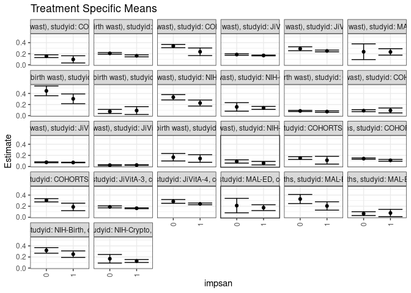

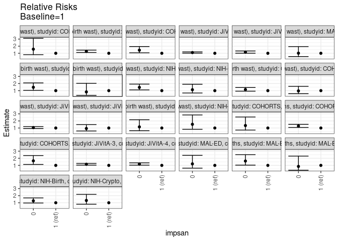

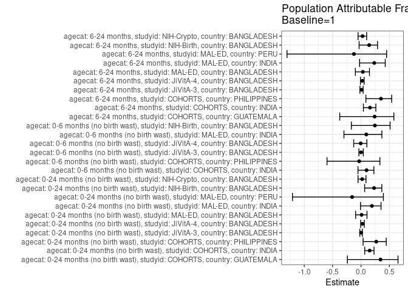

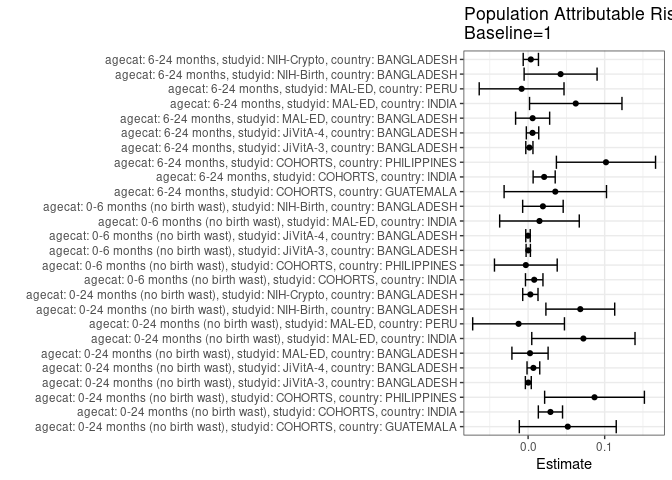

## Results Table

### Parameter: TSM

| agecat | studyid | country | intervention_level | baseline_level | estimate | ci_lower | ci_upper |
| --- | --- | --- | --- | --- | --- | --- | --- |
| 0-24 months (no birth wast) | COHORTS | GUATEMALA | 1 | NA | 0.0987654 | 0.0337559 | 0.1637749 |
| 0-24 months (no birth wast) | COHORTS | GUATEMALA | 0 | NA | 0.1558935 | 0.1305672 | 0.1812199 |
| 0-24 months (no birth wast) | COHORTS | INDIA | 1 | NA | 0.1629781 | 0.1446114 | 0.1813448 |
| 0-24 months (no birth wast) | COHORTS | INDIA | 0 | NA | 0.2070647 | 0.1927172 | 0.2214122 |
| 0-24 months (no birth wast) | COHORTS | PHILIPPINES | 1 | NA | 0.2356332 | 0.1671845 | 0.3040819 |
| 0-24 months (no birth wast) | COHORTS | PHILIPPINES | 0 | NA | 0.3385135 | 0.3090539 | 0.3679732 |
| 0-24 months (no birth wast) | JiVitA-3 | BANGLADESH | 1 | NA | 0.1690231 | 0.1623839 | 0.1756623 |
| 0-24 months (no birth wast) | JiVitA-3 | BANGLADESH | 0 | NA | 0.1858811 | 0.1720671 | 0.1996951 |
| 0-24 months (no birth wast) | JiVitA-4 | BANGLADESH | 1 | NA | 0.2508594 | 0.2352087 | 0.2665102 |
| 0-24 months (no birth wast) | JiVitA-4 | BANGLADESH | 0 | NA | 0.2901465 | 0.2547992 | 0.3254938 |
| 0-24 months (no birth wast) | MAL-ED | BANGLADESH | 1 | NA | 0.2330543 | 0.1751185 | 0.2909901 |
| 0-24 months (no birth wast) | MAL-ED | BANGLADESH | 0 | NA | 0.2363166 | 0.0946246 | 0.3780085 |
| 0-24 months (no birth wast) | MAL-ED | INDIA | 1 | NA | 0.3033500 | 0.2155839 | 0.3911160 |
| 0-24 months (no birth wast) | MAL-ED | INDIA | 0 | NA | 0.4465437 | 0.3589738 | 0.5341135 |
| 0-24 months (no birth wast) | MAL-ED | PERU | 1 | NA | 0.0923077 | 0.0218048 | 0.1628106 |
| 0-24 months (no birth wast) | MAL-ED | PERU | 0 | NA | 0.0757576 | 0.0388302 | 0.1126850 |
| 0-24 months (no birth wast) | NIH-Birth | BANGLADESH | 1 | NA | 0.2275139 | 0.1736195 | 0.2814083 |
| 0-24 months (no birth wast) | NIH-Birth | BANGLADESH | 0 | NA | 0.3316700 | 0.2833701 | 0.3799699 |
| 0-24 months (no birth wast) | NIH-Crypto | BANGLADESH | 1 | NA | 0.1397176 | 0.1130372 | 0.1663979 |
| 0-24 months (no birth wast) | NIH-Crypto | BANGLADESH | 0 | NA | 0.1576195 | 0.0807916 | 0.2344474 |
| 0-6 months (no birth wast) | COHORTS | INDIA | 1 | NA | 0.0735329 | 0.0600969 | 0.0869689 |
| 0-6 months (no birth wast) | COHORTS | INDIA | 0 | NA | 0.0850239 | 0.0746035 | 0.0954442 |
| 0-6 months (no birth wast) | COHORTS | PHILIPPINES | 1 | NA | 0.0936397 | 0.0493049 | 0.1379745 |
| 0-6 months (no birth wast) | COHORTS | PHILIPPINES | 0 | NA | 0.0900806 | 0.0722661 | 0.1078950 |
| 0-6 months (no birth wast) | JiVitA-3 | BANGLADESH | 1 | NA | 0.0714723 | 0.0669268 | 0.0760177 |
| 0-6 months (no birth wast) | JiVitA-3 | BANGLADESH | 0 | NA | 0.0753224 | 0.0667350 | 0.0839099 |
| 0-6 months (no birth wast) | JiVitA-4 | BANGLADESH | 1 | NA | 0.0254170 | 0.0201272 | 0.0307068 |
| 0-6 months (no birth wast) | JiVitA-4 | BANGLADESH | 0 | NA | 0.0236450 | 0.0138796 | 0.0334104 |
| 0-6 months (no birth wast) | MAL-ED | INDIA | 1 | NA | 0.1437523 | 0.0754336 | 0.2120710 |
| 0-6 months (no birth wast) | MAL-ED | INDIA | 0 | NA | 0.1666448 | 0.0995833 | 0.2337063 |
| 0-6 months (no birth wast) | NIH-Birth | BANGLADESH | 1 | NA | 0.0594210 | 0.0280565 | 0.0907855 |
| 0-6 months (no birth wast) | NIH-Birth | BANGLADESH | 0 | NA | 0.0905618 | 0.0606626 | 0.1204611 |
| 6-24 months | COHORTS | GUATEMALA | 1 | NA | 0.1125000 | 0.0432186 | 0.1817814 |
| 6-24 months | COHORTS | GUATEMALA | 0 | NA | 0.1516710 | 0.1264510 | 0.1768909 |
| 6-24 months | COHORTS | INDIA | 1 | NA | 0.1105780 | 0.0941224 | 0.1270336 |
| 6-24 months | COHORTS | INDIA | 0 | NA | 0.1417480 | 0.1296447 | 0.1538514 |
| 6-24 months | COHORTS | PHILIPPINES | 1 | NA | 0.1867115 | 0.1195152 | 0.2539078 |
| 6-24 months | COHORTS | PHILIPPINES | 0 | NA | 0.3064668 | 0.2773370 | 0.3355967 |
| 6-24 months | JiVitA-3 | BANGLADESH | 1 | NA | 0.1621727 | 0.1542854 | 0.1700601 |
| 6-24 months | JiVitA-3 | BANGLADESH | 0 | NA | 0.1872089 | 0.1696741 | 0.2047436 |
| 6-24 months | JiVitA-4 | BANGLADESH | 1 | NA | 0.2414973 | 0.2257941 | 0.2572005 |
| 6-24 months | JiVitA-4 | BANGLADESH | 0 | NA | 0.2859530 | 0.2515877 | 0.3203183 |
| 6-24 months | MAL-ED | BANGLADESH | 1 | NA | 0.1732673 | 0.1209651 | 0.2255695 |
| 6-24 months | MAL-ED | BANGLADESH | 0 | NA | 0.2105263 | 0.0806335 | 0.3404191 |
| 6-24 months | MAL-ED | INDIA | 1 | NA | 0.2038659 | 0.1286178 | 0.2791140 |
| 6-24 months | MAL-ED | INDIA | 0 | NA | 0.3289352 | 0.2470567 | 0.4108137 |
| 6-24 months | MAL-ED | PERU | 1 | NA | 0.0769231 | 0.0120199 | 0.1418262 |
| 6-24 months | MAL-ED | PERU | 0 | NA | 0.0656566 | 0.0310917 | 0.1002214 |
| 6-24 months | NIH-Birth | BANGLADESH | 1 | NA | 0.2509237 | 0.1925495 | 0.3092980 |
| 6-24 months | NIH-Birth | BANGLADESH | 0 | NA | 0.3187869 | 0.2685438 | 0.3690300 |
| 6-24 months | NIH-Crypto | BANGLADESH | 1 | NA | 0.1271740 | 0.1011297 | 0.1532183 |
| 6-24 months | NIH-Crypto | BANGLADESH | 0 | NA | 0.1678298 | 0.0907392 | 0.2449205 |

### Parameter: E(Y)

| agecat | studyid | country | intervention_level | baseline_level | estimate | ci_lower | ci_upper |
| --- | --- | --- | --- | --- | --- | --- | --- |
| 0-24 months (no birth wast) | COHORTS | GUATEMALA | NA | NA | 0.1505747 | 0.1267966 | 0.1743528 |
| 0-24 months (no birth wast) | COHORTS | INDIA | NA | NA | 0.1921440 | 0.1814014 | 0.2028866 |
| 0-24 months (no birth wast) | COHORTS | PHILIPPINES | NA | NA | 0.3223629 | 0.2957407 | 0.3489850 |
| 0-24 months (no birth wast) | JiVitA-3 | BANGLADESH | NA | NA | 0.1693080 | 0.1640179 | 0.1745980 |
| 0-24 months (no birth wast) | JiVitA-4 | BANGLADESH | NA | NA | 0.2577588 | 0.2441239 | 0.2713937 |
| 0-24 months (no birth wast) | MAL-ED | BANGLADESH | NA | NA | 0.2355372 | 0.1819640 | 0.2891104 |
| 0-24 months (no birth wast) | MAL-ED | INDIA | NA | NA | 0.3755459 | 0.3126876 | 0.4384041 |
| 0-24 months (no birth wast) | MAL-ED | PERU | NA | NA | 0.0798479 | 0.0470264 | 0.1126695 |
| 0-24 months (no birth wast) | NIH-Birth | BANGLADESH | NA | NA | 0.2956811 | 0.2591967 | 0.3321655 |
| 0-24 months (no birth wast) | NIH-Crypto | BANGLADESH | NA | NA | 0.1426649 | 0.1175009 | 0.1678289 |
| 0-6 months (no birth wast) | COHORTS | INDIA | NA | NA | 0.0815160 | 0.0737115 | 0.0893204 |
| 0-6 months (no birth wast) | COHORTS | PHILIPPINES | NA | NA | 0.0906780 | 0.0742871 | 0.1070688 |
| 0-6 months (no birth wast) | JiVitA-3 | BANGLADESH | NA | NA | 0.0716602 | 0.0680237 | 0.0752968 |
| 0-6 months (no birth wast) | JiVitA-4 | BANGLADESH | NA | NA | 0.0252781 | 0.0205710 | 0.0299851 |
| 0-6 months (no birth wast) | MAL-ED | INDIA | NA | NA | 0.1585903 | 0.1109652 | 0.2062154 |
| 0-6 months (no birth wast) | NIH-Birth | BANGLADESH | NA | NA | 0.0787671 | 0.0569010 | 0.1006332 |
| 6-24 months | COHORTS | GUATEMALA | NA | NA | 0.1480186 | 0.1242431 | 0.1717942 |
| 6-24 months | COHORTS | INDIA | NA | NA | 0.1315423 | 0.1221962 | 0.1408884 |
| 6-24 months | COHORTS | PHILIPPINES | NA | NA | 0.2884097 | 0.2617831 | 0.3150363 |
| 6-24 months | JiVitA-3 | BANGLADESH | NA | NA | 0.1638320 | 0.1577097 | 0.1699543 |
| 6-24 months | JiVitA-4 | BANGLADESH | NA | NA | 0.2472801 | 0.2337480 | 0.2608122 |
| 6-24 months | MAL-ED | BANGLADESH | NA | NA | 0.1791667 | 0.1305478 | 0.2277856 |
| 6-24 months | MAL-ED | INDIA | NA | NA | 0.2660944 | 0.2092298 | 0.3229590 |
| 6-24 months | MAL-ED | PERU | NA | NA | 0.0684411 | 0.0378665 | 0.0990157 |
| 6-24 months | NIH-Birth | BANGLADESH | NA | NA | 0.2933579 | 0.2549918 | 0.3317241 |
| 6-24 months | NIH-Crypto | BANGLADESH | NA | NA | 0.1307371 | 0.1060790 | 0.1553953 |

### Parameter: RR

| agecat | studyid | country | intervention_level | baseline_level | estimate | ci_lower | ci_upper |
| --- | --- | --- | --- | --- | --- | --- | --- |
| 0-24 months (no birth wast) | COHORTS | GUATEMALA | 1 | 1 | 1.0000000 | 1.0000000 | 1.000000 |
| 0-24 months (no birth wast) | COHORTS | GUATEMALA | 0 | 1 | 1.5784221 | 0.8012777 | 3.109304 |
| 0-24 months (no birth wast) | COHORTS | INDIA | 1 | 1 | 1.0000000 | 1.0000000 | 1.000000 |
| 0-24 months (no birth wast) | COHORTS | INDIA | 0 | 1 | 1.2705058 | 1.1135993 | 1.449520 |
| 0-24 months (no birth wast) | COHORTS | PHILIPPINES | 1 | 1 | 1.0000000 | 1.0000000 | 1.000000 |
| 0-24 months (no birth wast) | COHORTS | PHILIPPINES | 0 | 1 | 1.4366123 | 1.0608600 | 1.945455 |
| 0-24 months (no birth wast) | JiVitA-3 | BANGLADESH | 1 | 1 | 1.0000000 | 1.0000000 | 1.000000 |
| 0-24 months (no birth wast) | JiVitA-3 | BANGLADESH | 0 | 1 | 1.0997380 | 1.0146011 | 1.192019 |
| 0-24 months (no birth wast) | JiVitA-4 | BANGLADESH | 1 | 1 | 1.0000000 | 1.0000000 | 1.000000 |
| 0-24 months (no birth wast) | JiVitA-4 | BANGLADESH | 0 | 1 | 1.1566098 | 1.0110634 | 1.323108 |
| 0-24 months (no birth wast) | MAL-ED | BANGLADESH | 1 | 1 | 1.0000000 | 1.0000000 | 1.000000 |
| 0-24 months (no birth wast) | MAL-ED | BANGLADESH | 0 | 1 | 1.0139980 | 0.5301250 | 1.939528 |
| 0-24 months (no birth wast) | MAL-ED | INDIA | 1 | 1 | 1.0000000 | 1.0000000 | 1.000000 |
| 0-24 months (no birth wast) | MAL-ED | INDIA | 0 | 1 | 1.4720413 | 1.0397615 | 2.084041 |
| 0-24 months (no birth wast) | MAL-ED | PERU | 1 | 1 | 1.0000000 | 1.0000000 | 1.000000 |
| 0-24 months (no birth wast) | MAL-ED | PERU | 0 | 1 | 0.8207071 | 0.3316556 | 2.030902 |
| 0-24 months (no birth wast) | NIH-Birth | BANGLADESH | 1 | 1 | 1.0000000 | 1.0000000 | 1.000000 |
| 0-24 months (no birth wast) | NIH-Birth | BANGLADESH | 0 | 1 | 1.4578008 | 1.1056410 | 1.922128 |
| 0-24 months (no birth wast) | NIH-Crypto | BANGLADESH | 1 | 1 | 1.0000000 | 1.0000000 | 1.000000 |
| 0-24 months (no birth wast) | NIH-Crypto | BANGLADESH | 0 | 1 | 1.1281291 | 0.6681604 | 1.904745 |
| 0-6 months (no birth wast) | COHORTS | INDIA | 1 | 1 | 1.0000000 | 1.0000000 | 1.000000 |
| 0-6 months (no birth wast) | COHORTS | INDIA | 0 | 1 | 1.1562698 | 0.9279071 | 1.440834 |
| 0-6 months (no birth wast) | COHORTS | PHILIPPINES | 1 | 1 | 1.0000000 | 1.0000000 | 1.000000 |
| 0-6 months (no birth wast) | COHORTS | PHILIPPINES | 0 | 1 | 0.9619907 | 0.5758725 | 1.606998 |
| 0-6 months (no birth wast) | JiVitA-3 | BANGLADESH | 1 | 1 | 1.0000000 | 1.0000000 | 1.000000 |
| 0-6 months (no birth wast) | JiVitA-3 | BANGLADESH | 0 | 1 | 1.0538694 | 0.9266496 | 1.198555 |
| 0-6 months (no birth wast) | JiVitA-4 | BANGLADESH | 1 | 1 | 1.0000000 | 1.0000000 | 1.000000 |
| 0-6 months (no birth wast) | JiVitA-4 | BANGLADESH | 0 | 1 | 0.9302836 | 0.5847402 | 1.480021 |
| 0-6 months (no birth wast) | MAL-ED | INDIA | 1 | 1 | 1.0000000 | 1.0000000 | 1.000000 |
| 0-6 months (no birth wast) | MAL-ED | INDIA | 0 | 1 | 1.1592495 | 0.6200897 | 2.167202 |
| 0-6 months (no birth wast) | NIH-Birth | BANGLADESH | 1 | 1 | 1.0000000 | 1.0000000 | 1.000000 |
| 0-6 months (no birth wast) | NIH-Birth | BANGLADESH | 0 | 1 | 1.5240706 | 0.8177305 | 2.840534 |
| 6-24 months | COHORTS | GUATEMALA | 1 | 1 | 1.0000000 | 1.0000000 | 1.000000 |
| 6-24 months | COHORTS | GUATEMALA | 0 | 1 | 1.3481862 | 0.7123909 | 2.551417 |
| 6-24 months | COHORTS | INDIA | 1 | 1 | 1.0000000 | 1.0000000 | 1.000000 |
| 6-24 months | COHORTS | INDIA | 0 | 1 | 1.2818827 | 1.0807954 | 1.520383 |
| 6-24 months | COHORTS | PHILIPPINES | 1 | 1 | 1.0000000 | 1.0000000 | 1.000000 |
| 6-24 months | COHORTS | PHILIPPINES | 0 | 1 | 1.6413925 | 1.1310489 | 2.382010 |
| 6-24 months | JiVitA-3 | BANGLADESH | 1 | 1 | 1.0000000 | 1.0000000 | 1.000000 |
| 6-24 months | JiVitA-3 | BANGLADESH | 0 | 1 | 1.1543794 | 1.0414181 | 1.279594 |
| 6-24 months | JiVitA-4 | BANGLADESH | 1 | 1 | 1.0000000 | 1.0000000 | 1.000000 |
| 6-24 months | JiVitA-4 | BANGLADESH | 0 | 1 | 1.1840837 | 1.0361787 | 1.353101 |
| 6-24 months | MAL-ED | BANGLADESH | 1 | 1 | 1.0000000 | 1.0000000 | 1.000000 |
| 6-24 months | MAL-ED | BANGLADESH | 0 | 1 | 1.2150376 | 0.6113418 | 2.414879 |
| 6-24 months | MAL-ED | INDIA | 1 | 1 | 1.0000000 | 1.0000000 | 1.000000 |
| 6-24 months | MAL-ED | INDIA | 0 | 1 | 1.6134881 | 1.0370571 | 2.510319 |
| 6-24 months | MAL-ED | PERU | 1 | 1 | 1.0000000 | 1.0000000 | 1.000000 |
| 6-24 months | MAL-ED | PERU | 0 | 1 | 0.8535354 | 0.3157269 | 2.307445 |
| 6-24 months | NIH-Birth | BANGLADESH | 1 | 1 | 1.0000000 | 1.0000000 | 1.000000 |
| 6-24 months | NIH-Birth | BANGLADESH | 0 | 1 | 1.2704533 | 0.9614324 | 1.678799 |
| 6-24 months | NIH-Crypto | BANGLADESH | 1 | 1 | 1.0000000 | 1.0000000 | 1.000000 |
| 6-24 months | NIH-Crypto | BANGLADESH | 0 | 1 | 1.3196865 | 0.7980774 | 2.182210 |

### Parameter: PAR

| agecat | studyid | country | intervention_level | baseline_level | estimate | ci_lower | ci_upper |
| --- | --- | --- | --- | --- | --- | --- | --- |
| 0-24 months (no birth wast) | COHORTS | GUATEMALA | 1 | NA | 0.0518093 | -0.0114732 | 0.1150918 |
| 0-24 months (no birth wast) | COHORTS | INDIA | 1 | NA | 0.0291658 | 0.0133547 | 0.0449770 |
| 0-24 months (no birth wast) | COHORTS | PHILIPPINES | 1 | NA | 0.0867297 | 0.0215861 | 0.1518732 |
| 0-24 months (no birth wast) | JiVitA-3 | BANGLADESH | 1 | NA | 0.0002849 | -0.0035628 | 0.0041325 |
| 0-24 months (no birth wast) | JiVitA-4 | BANGLADESH | 1 | NA | 0.0068993 | -0.0013975 | 0.0151962 |
| 0-24 months (no birth wast) | MAL-ED | BANGLADESH | 1 | NA | 0.0024829 | -0.0211485 | 0.0261143 |
| 0-24 months (no birth wast) | MAL-ED | INDIA | 1 | NA | 0.0721959 | 0.0047779 | 0.1396139 |
| 0-24 months (no birth wast) | MAL-ED | PERU | 1 | NA | -0.0124598 | -0.0723842 | 0.0474646 |
| 0-24 months (no birth wast) | NIH-Birth | BANGLADESH | 1 | NA | 0.0681671 | 0.0232427 | 0.1130916 |
| 0-24 months (no birth wast) | NIH-Crypto | BANGLADESH | 1 | NA | 0.0029473 | -0.0070392 | 0.0129338 |
| 0-6 months (no birth wast) | COHORTS | INDIA | 1 | NA | 0.0079831 | -0.0034244 | 0.0193905 |
| 0-6 months (no birth wast) | COHORTS | PHILIPPINES | 1 | NA | -0.0029618 | -0.0439243 | 0.0380008 |
| 0-6 months (no birth wast) | JiVitA-3 | BANGLADESH | 1 | NA | 0.0001880 | -0.0026257 | 0.0030017 |
| 0-6 months (no birth wast) | JiVitA-4 | BANGLADESH | 1 | NA | -0.0001389 | -0.0030632 | 0.0027854 |
| 0-6 months (no birth wast) | MAL-ED | INDIA | 1 | NA | 0.0148380 | -0.0371423 | 0.0668184 |
| 0-6 months (no birth wast) | NIH-Birth | BANGLADESH | 1 | NA | 0.0193461 | -0.0071112 | 0.0458034 |
| 6-24 months | COHORTS | GUATEMALA | 1 | NA | 0.0355186 | -0.0313402 | 0.1023775 |
| 6-24 months | COHORTS | INDIA | 1 | NA | 0.0209643 | 0.0065468 | 0.0353818 |
| 6-24 months | COHORTS | PHILIPPINES | 1 | NA | 0.1016982 | 0.0369579 | 0.1664385 |
| 6-24 months | JiVitA-3 | BANGLADESH | 1 | NA | 0.0016593 | -0.0030212 | 0.0063397 |
| 6-24 months | JiVitA-4 | BANGLADESH | 1 | NA | 0.0057828 | -0.0023260 | 0.0138916 |
| 6-24 months | MAL-ED | BANGLADESH | 1 | NA | 0.0058993 | -0.0163386 | 0.0281373 |
| 6-24 months | MAL-ED | INDIA | 1 | NA | 0.0622285 | 0.0018801 | 0.1225770 |
| 6-24 months | MAL-ED | PERU | 1 | NA | -0.0084820 | -0.0638448 | 0.0468808 |
| 6-24 months | NIH-Birth | BANGLADESH | 1 | NA | 0.0424342 | -0.0052082 | 0.0900767 |
| 6-24 months | NIH-Crypto | BANGLADESH | 1 | NA | 0.0035631 | -0.0063911 | 0.0135173 |

### Parameter: PAF

| agecat | studyid | country | intervention_level | baseline_level | estimate | ci_lower | ci_upper |
| --- | --- | --- | --- | --- | --- | --- | --- |
| 0-24 months (no birth wast) | COHORTS | GUATEMALA | 1 | NA | 0.3440769 | -0.2397390 | 0.6529632 |
| 0-24 months (no birth wast) | COHORTS | INDIA | 1 | NA | 0.1517916 | 0.0656703 | 0.2299746 |
| 0-24 months (no birth wast) | COHORTS | PHILIPPINES | 1 | NA | 0.2690436 | 0.0369126 | 0.4452245 |
| 0-24 months (no birth wast) | JiVitA-3 | BANGLADESH | 1 | NA | 0.0016825 | -0.0213056 | 0.0241532 |
| 0-24 months (no birth wast) | JiVitA-4 | BANGLADESH | 1 | NA | 0.0267666 | -0.0059289 | 0.0583994 |
| 0-24 months (no birth wast) | MAL-ED | BANGLADESH | 1 | NA | 0.0105415 | -0.0950075 | 0.1059166 |
| 0-24 months (no birth wast) | MAL-ED | INDIA | 1 | NA | 0.1922426 | -0.0086292 | 0.3531101 |
| 0-24 months (no birth wast) | MAL-ED | PERU | 1 | NA | -0.1560440 | -1.2084404 | 0.3948500 |
| 0-24 months (no birth wast) | NIH-Birth | BANGLADESH | 1 | NA | 0.2305428 | 0.0640307 | 0.3674318 |
| 0-24 months (no birth wast) | NIH-Crypto | BANGLADESH | 1 | NA | 0.0206588 | -0.0518405 | 0.0881610 |
| 0-6 months (no birth wast) | COHORTS | INDIA | 1 | NA | 0.0979329 | -0.0531670 | 0.2273542 |
| 0-6 months (no birth wast) | COHORTS | PHILIPPINES | 1 | NA | -0.0326624 | -0.5992673 | 0.3331998 |
| 0-6 months (no birth wast) | JiVitA-3 | BANGLADESH | 1 | NA | 0.0026231 | -0.0374217 | 0.0411222 |
| 0-6 months (no birth wast) | JiVitA-4 | BANGLADESH | 1 | NA | -0.0054955 | -0.1282176 | 0.1038775 |
| 0-6 months (no birth wast) | MAL-ED | INDIA | 1 | NA | 0.0935618 | -0.3005632 | 0.3682505 |
| 0-6 months (no birth wast) | NIH-Birth | BANGLADESH | 1 | NA | 0.2456113 | -0.1704077 | 0.5137572 |
| 6-24 months | COHORTS | GUATEMALA | 1 | NA | 0.2399606 | -0.3748179 | 0.5798281 |
| 6-24 months | COHORTS | INDIA | 1 | NA | 0.1593730 | 0.0428074 | 0.2617434 |
| 6-24 months | COHORTS | PHILIPPINES | 1 | NA | 0.3526172 | 0.0861158 | 0.5414030 |
| 6-24 months | JiVitA-3 | BANGLADESH | 1 | NA | 0.0101278 | -0.0188789 | 0.0383088 |
| 6-24 months | JiVitA-4 | BANGLADESH | 1 | NA | 0.0233858 | -0.0099750 | 0.0556445 |
| 6-24 months | MAL-ED | BANGLADESH | 1 | NA | 0.0329265 | -0.0992978 | 0.1492469 |
| 6-24 months | MAL-ED | INDIA | 1 | NA | 0.2338588 | -0.0255771 | 0.4276663 |
| 6-24 months | MAL-ED | PERU | 1 | NA | -0.1239316 | -1.3051391 | 0.4519974 |
| 6-24 months | NIH-Birth | BANGLADESH | 1 | NA | 0.1446499 | -0.0334354 | 0.2920469 |
| 6-24 months | NIH-Crypto | BANGLADESH | 1 | NA | 0.0272541 | -0.0518052 | 0.1003709 |